# Project1

$$E(r(X)) = \mu_r = 0$$

$$Var(r(X)) = \sigma_r^2$$
$$Cor(r(X), r(X')) = \rho_r(\tau)$$

$$\tau = \frac{| X - X'|}{10}$$

$(r(x) | x\in D = [1, 50]\subset \mathbb{R}^1)$

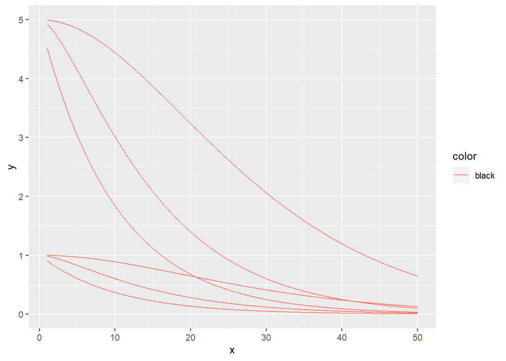

```r
p1
```

```r
p2
```

[output not shown]

[output cut: 17 more lines]

# Problem 1b) Want to specify pdf of a guassian prior rf.

Let ${\boldsymbol{\mathbf{r}}} \sim p({\boldsymbol{\mathbf{r}}}) = \phi_n({\boldsymbol{\mathbf{r}}} | \mu_r{\boldsymbol{\mathbf{1}}}_n, \sigma^2_r {\boldsymbol{\mathbf{\Sigma}}}_r^\rho$ With ${\boldsymbol{\mathbf{\Sigma}}}_r^p$ covariance matrix defined by the corrolation function given in problem 1a) for a given $\kappa$. To start off we select $\kappa = 0.5$.

# Problem 1c)

As we both $\epsilon(\dot)$ and $r(\dot)$ ar gaussian, a linear product of the two would also be.

We further note:
$$E(d(x)) = E(r(x)) + E((\epsilon(x))) = 0$$

When $x\neq x'$
$$Cov(d(x), d(x')) = Cov(r(x)+\epsilon(x), r(x') + \epsilon(x')) = Cov(r(x), r(x')) + Cov(\epsilon(x), \epsilon(x')) = \sigma_r^2\rho_r(\tau)$$
And:
$$Cov(d(x), d(x)) = Cov(r(x)+\epsilon(x), r(x) + \epsilon(x)) = Cov(r(x), r(x)) + Cov(\epsilon(x), \epsilon(x)) = \sigma_r^2\rho_r(\tau) + \sigma_e^2$$

So in general we see:
$$Cov({\boldsymbol{\mathbf{d}}}({\boldsymbol{\mathbf{x}}}), {\boldsymbol{\mathbf{d}}}({\boldsymbol{\mathbf{x}}}')) = \sigma^2_e {\boldsymbol{\mathbf{I}}}_k +\sigma^2_r{\boldsymbol{\mathbf{\Sigma}}}_\rho^d$$

With the corresponding likelihood function:
$$L(\sigma_e^2 | {\boldsymbol{\mathbf{d}}}({\boldsymbol{\mathbf{x}}}), \sigma_r^2)=p({\boldsymbol{\mathbf{d}}}({\boldsymbol{\mathbf{x}}})|\sigma_r^2, \sigma_e^2)$$
The integral
$$\int_{0}^{\infty}p({\boldsymbol{\mathbf{d}}}({\boldsymbol{\mathbf{x}}})|\sigma_r^2, \sigma_e^2) d\sigma^2$$
goes to infinity, thus not a pdf. If we try to draw sigmas beliving L is a pdf, we would expect values to goes to infinity, which would give us more variance than we have.

# Problem 1d)

${\boldsymbol{\mathbf{d}}}({\boldsymbol{\mathbf{x}}})$ and ${\boldsymbol{\mathbf{l}}}({\boldsymbol{\mathbf{x}}})$ are both multivariate gaussian so ${\boldsymbol{\mathbf{l}}} | {\boldsymbol{\mathbf{d}}}$ would also be. Have:

$${\boldsymbol{\mathbf{\mu}}}_{{\boldsymbol{\mathbf{l}}} | {\boldsymbol{\mathbf{d}}}} = {\boldsymbol{\mathbf{\mu}}}_l + {\boldsymbol{\mathbf{\Sigma}}}_{{\boldsymbol{\mathbf{l}}}, {\boldsymbol{\mathbf{d}}}}^\rho {\boldsymbol{\mathbf{\Sigma}}}_{{\boldsymbol{\mathbf{d}}}, {\boldsymbol{\mathbf{d}}}}^{-1}({\boldsymbol{\mathbf{d}}} - {\boldsymbol{\mathbf{\mu}}}_{{\boldsymbol{\mathbf{d}}}})$$

$${\boldsymbol{\mathbf{\Sigma}}}_{{\boldsymbol{\mathbf{l}}} | {\boldsymbol{\mathbf{d}}}}^\rho = {\boldsymbol{\mathbf{\Sigma}}}_{{\boldsymbol{\mathbf{l}}}}^\rho - {\boldsymbol{\mathbf{\Sigma}}}_{{\boldsymbol{\mathbf{l}}}, {\boldsymbol{\mathbf{d}}}}^\rho {\boldsymbol{\mathbf{\Sigma}}}_{{\boldsymbol{\mathbf{d}}}, {\boldsymbol{\mathbf{d}}}}^{-1}\Sigma_{{\boldsymbol{\mathbf{d}}}, {\boldsymbol{\mathbf{l}}}}^\rho$$